# scRNA

Maria Lucia Romero

11/25/2021

```r
library(dplyr)
library(reshape2)
library(kableExtra)
library(ggplot2)
library(ggpubr)
library(ggrepel)
library(corrplot)
library(RColorBrewer)
library(plyr)
```

# Loading data

```r
RNAseq.data.mapping<-read.csv("/Users/mlromeror/Documents/Sample co7dzuup_xuczw9vc/data/data/cellranger_mapping_metrics_hashed.csv")
Multiome.RNAseq.data.mapping<-read.csv("/Users/mlromeror/Documents/Sample co7dzuup_xuczw9vc/data/data/cellranger_mapping_metrics_multiome.csv")
```

# RNAseq Mapping data Table

Visualization of mapping data

|  | gem_id | Estimated.Number.of.Cells | Mean.Reads.per.Cell | Median.Genes.per.Cell | Number.of.Reads | Valid.Barcodes | Sequencing.Saturation | Q30.Bases.in.Barcode | Q30.Bases.in.RNA.Read | Q30.Bases.in.UMI | Reads.Mapped.to.Genome | Reads.Mapped.Confidently.to.Genome | Reads.Mapped.Confidently.to.Intergenic.Regions | Reads.Mapped.Confidently.to.Intronic.Regions | Reads.Mapped.Confidently.to.Exonic.Regions | Reads.Mapped.Confidently.to.Transcriptome | Reads.Mapped.Antisense.to.Gene | Fraction.Reads.in.Cells | Total.Genes.Detected | Median.UMI.Counts.per.Cell | Antibody..Number.of.Reads | Antibody..Mean.Reads.per.Cell | Antibody..Valid.Barcodes | Antibody..Sequencing.Saturation | Antibody..Q30.Bases.in.Barcode | Antibody..Q30.Bases.in.Antibody.Read | Antibody..Q30.Bases.in.UMI | Antibody..Fraction.Antibody.Reads | Antibody..Fraction.Antibody.Reads.Usable | … |
| --- | --- | --- | --- | --- | --- | --- | --- | --- | --- | --- | --- | --- | --- | --- | --- | --- | --- | --- | --- | --- | --- | --- | --- | --- | --- | --- | --- | --- | --- | --- |
| 1 | izi9unx1_8qdzhivu | 19,580 | 20,071 | 565 | 393,002,015 | 97.4% | 62.4% | 97.4% | 91.6% | 97.4% | 96.9% | 90.6% | 5.5% | 26.6% | 58.5% | 56.0% | 1.3% | 83.3% | 25,933 | 1,576 | 8,720,503 | 445 | 98.8% | 23.4% | 99.5% | 43.0% | 99.4% | 95.2% | 48.3% | … |
| 2 | d8kwy76j_7blj9otf | 23,458 | 21,100 | 1,176 | 494,981,784 | 97.1% | 41.1% | 96.9% | 80.8% | 96.7% | 77.5% | 74.2% | 3.8% | 28.3% | 42.1% | 38.9% | 1.9% | 90.6% | 26,588 | 2,800 | 38,157,086 | 1,626 | 99.0% | 33.3% | 97.7% | 65.1% | 97.6% | 96.5% | 60.8% | … |
| 3 | giz3qso4_783dbpu6 | 24,248 | 32,838 | 1,440 | 796,264,647 | 97.0% | 52.1% | 96.1% | 80.7% | 96.3% | 79.4% | 76.3% | 3.4% | 24.3% | 48.7% | 44.8% | 1.8% | 88.4% | 27,319 | 3,975 | 59,277,922 | 2,444 | 99.0% | 35.1% | 97.7% | 64.8% | 97.6% | 97.1% | 63.4% | … |
| 4 | i5udk3x0_57gv6ncx | 18,680 | 23,720 | 1,312 | 443,092,189 | 97.4% | 41.8% | 96.2% | 80.3% | 96.1% | 78.3% | 74.7% | 3.6% | 21.5% | 49.6% | 45.9% | 1.6% | 87.2% | 26,161 | 3,474 | 29,588,501 | 1,583 | 98.9% | 35.6% | 97.8% | 64.8% | 97.6% | 96.4% | 47.2% | … |
| 5 | umt51kfr_p8ei65ms | 21,126 | 30,271 | 1,476 | 639,514,672 | 97.4% | 47.2% | 96.2% | 80.0% | 96.1% | 76.6% | 73.2% | 3.6% | 22.4% | 47.1% | 43.7% | 1.6% | 89.8% | 26,885 | 3,875 | 20,489,244 | 969 | 98.9% | 33.7% | 97.7% | 65.5% | 97.5% | 96.8% | 51.6% | … |
| 6 | bw94nf57_vm85woki | 24,024 | 26,566 | 1,481 | 638,235,233 | 96.6% | 48.6% | 97.0% | 94.5% | 97.0% | 96.7% | 91.6% | 4.5% | 31.6% | 55.5% | 50.6% | 3.3% | 85.2% | 27,026 | 3,920 | 22,830,949 | 950 | 98.8% | 45.3% | 97.8% | 61.7% | 97.4% | 92.9% | 51.8% | … |
| 7 | ggq3nifm_jkilwp1x | 27,379 | 26,026 | 1,451 | 712,583,457 | 96.8% | 49.0% | 96.9% | 95.0% | 96.9% | 97.1% | 92.3% | 4.4% | 30.4% | 57.5% | 52.8% | 3.1% | 86.4% | 27,247 | 3,949 | 22,947,172 | 838 | 98.9% | 48.1% | 97.8% | 61.0% | 97.4% | 92.7% | 52.0% | … |
| 8 | dvcbn9p8_ix0j3k8b | 28,659 | 28,604 | 1,481 | 819,787,582 | 97.0% | 52.3% | 96.9% | 95.0% | 97.1% | 97.5% | 92.3% | 4.4% | 30.3% | 57.7% | 53.4% | 2.8% | 83.0% | 27,755 | 3,954 | 25,757,716 | 898 | 99.0% | 44.6% | 98.4% | 64.2% | 98.5% | 92.6% | 50.9% | … |
| 9 | ff8s19u3_7e96iusr | 30,163 | 30,092 | 1,595 | 907,683,518 | 97.1% | 51.7% | 97.5% | 95.7% | 97.7% | 97.6% | 93.4% | 4.1% | 29.3% | 60.1% | 56.2% | 2.5% | 84.2% | 27,903 | 4,608 | 28,053,180 | 930 | 99.0% | 40.5% | 98.3% | 64.3% | 98.4% | 93.3% | 53.6% | … |
| 10 | dvdzq8et_eot75su8 | 19,053 | 49,439 | 1,924 | 941,975,034 | 96.8% | 65.2% | 96.3% | 93.9% | 95.3% | 97.4% | 92.8% | 4.3% | 24.3% | 64.1% | 60.8% | 1.9% | 85.0% | 27,080 | 5,888 | 157,876,755 | 8,286 | 98.8% | 63.7% | 97.7% | 68.2% | 97.7% | 91.7% | 46.3% | … |
| 11 | md651vbh_eymr91s7 | 19,024 | 28,417 | 1,738 | 540,617,235 | 96.7% | 41.9% | 96.9% | 93.1% | 97.1% | 96.1% | 88.5% | 5.6% | 39.4% | 43.4% | 39.4% | 2.9% | 89.0% | 27,364 | 4,652 | 259,411,291 | 13,636 | 98.8% | 36.2% | 97.1% | 69.3% | 97.1% | 96.0% | 56.4% | … |
| 12 | n1b3su0a_l7shyi35 | 12,826 | 57,650 | 1,714 | 739,430,260 | 96.5% | 68.3% | 96.9% | 93.1% | 97.0% | 95.9% | 86.5% | 6.7% | 34.5% | 45.4% | 42.2% | 2.1% | 87.2% | 26,700 | 4,754 | 179,391,632 | 13,986 | 98.9% | 50.5% | 97.0% | 68.5% | 97.1% | 96.1% | 44.0% | … |
| 13 | x739d5z1_dsamhgey | 15,457 | 41,386 | 1,676 | 639,715,891 | 96.9% | 63.5% | 96.8% | 92.5% | 97.0% | 97.3% | 91.5% | 4.7% | 26.8% | 60.1% | 56.5% | 2.1% | 81.8% | 26,501 | 4,746 | 186,717,642 | 12,079 | 98.8% | 67.5% | 97.8% | 68.4% | 97.7% | 91.3% | 38.6% | … |
| 14 | bz5rpwtv_kg7w108r | 24,661 | 35,722 | 1,630 | 880,952,803 | 96.7% | 58.6% | 97.1% | 95.1% | 97.0% | 96.9% | 92.1% | 4.1% | 24.7% | 63.2% | 59.6% | 2.3% | 84.4% | 27,130 | 4,716 | 30,839,209 | 1,250 | 98.9% | 50.2% | 97.8% | 60.6% | 97.6% | 93.0% | 48.6% | … |
| 15 | wf4su8ny_h4yj8bv7 | 24,646 | 19,400 | 1,312 | 478,139,842 | 96.6% | 45.3% | 96.6% | 94.5% | 96.6% | 97.5% | 92.6% | 4.1% | 25.3% | 63.1% | 59.4% | 2.4% | 84.3% | 26,431 | 3,399 | 34,461,302 | 1,398 | 98.9% | 52.4% | 97.8% | 60.6% | 97.6% | 93.2% | 45.5% | … |
| 16 | kjzv2rwx_sfomyxok | 29,443 | 25,818 | 1,384 | 760,188,511 | 98.1% | 55.1% | 97.1% | 94.5% | 96.8% | 97.0% | 93.1% | 5.2% | 33.7% | 54.1% | 51.2% | 1.8% | 88.4% | 26,877 | 3,929 | 62,416,515 | 2,119 | 99.4% | 45.3% | 97.5% | 62.1% | 97.0% | 94.6% | 63.2% | … |
| 17 | v8g80gtx_ps9bamz7 | 29,401 | 26,568 | 1,449 | 781,131,740 | 97.3% | 51.0% | 97.1% | 94.4% | 96.7% | 96.4% | 92.0% | 5.4% | 32.0% | 54.6% | 51.6% | 1.8% | 87.9% | 27,087 | 4,472 | 44,542,968 | 1,515 | 99.0% | 57.4% | 97.6% | 61.4% | 97.0% | 91.7% | 56.9% | … |
| 18 | ejto2bae_y5mydeam | 22,847 | 37,972 | 1,690 | 867,549,060 | 97.9% | 64.6% | 97.4% | 95.2% | 97.0% | 98.0% | 94.2% | 4.6% | 24.7% | 64.9% | 61.9% | 1.8% | 88.5% | 26,938 | 5,884 | 55,571,687 | 2,432 | 99.2% | 49.3% | 97.3% | 61.8% | 96.6% | 95.2% | 53.5% | … |
| 19 | z3of7uaq_mzbhy4tt | 23,056 | 36,070 | 1,676 | 831,630,600 | 98.0% | 62.3% | 97.3% | 95.1% | 96.9% | 98.0% | 94.1% | 4.6% | 23.9% | 65.6% | 62.6% | 1.7% | 88.4% | 26,962 | 5,909 | 61,026,456 | 2,646 | 99.3% | 49.3% | 97.4% | 61.7% | 96.7% | 95.4% | 56.9% | … |

# Multiome Mapping data table

Visualization of mapping data

|  | Sample.ID | Pipeline.version | Genome | Estimated.number.of.cells | ATAC.Confidently.mapped.read.pairs | ATAC.Fraction.of.genome.in.peaks | ATAC.Fraction.of.high.quality.fragments.in.cells | ATAC.Fraction.of.high.quality.fragments.overlapping.TSS | ATAC.Fraction.of.high.quality.fragments.overlapping.peaks | ATAC.Fraction.of.transposition.events.in.peaks.in.cells | ATAC.Mean.raw.read.pairs.per.cell | ATAC.Median.high.quality.fragments.per.cell | ATAC.Non.nuclear.read.pairs | ATAC.Number.of.peaks | ATAC.Percent.duplicates | ATAC.Q30.bases.in.barcode | ATAC.Q30.bases.in.read.1 | ATAC.Q30.bases.in.read.2 | ATAC.Q30.bases.in.sample.index.i1 | ATAC.Sequenced.read.pairs | ATAC.TSS.enrichment.score | ATAC.Unmapped.read.pairs | ATAC.Valid.barcodes | Feature.linkages.detected | GEX.Fraction.of.transcriptomic.reads.in.cells | GEX.Mean.raw.reads.per.cell | GEX.Median.UMI.counts.per.cell | GEX.Median.genes.per.cell | GEX.Percent.duplicates | … |
| --- | --- | --- | --- | --- | --- | --- | --- | --- | --- | --- | --- | --- | --- | --- | --- | --- | --- | --- | --- | --- | --- | --- | --- | --- | --- | --- | --- | --- | --- | --- |
| 1 | qmzb59ew_t11l8dzm | cellranger-arc-1.0.0 | GRCh38 | 5530 | 0.90964 | 0.05144 | 0.90915 | 0.44015 | 0.77105 | 0.75653 | 57807.81 | 8271 | 0.02425 | 132440 | 0.70263 | 0.91053 | 0.96303 | 0.96083 | NA | 319677205 | 11.26773 | 0.01051 | 0.97903 | 151554 | 0.90220 | 39397.02 | 4847.0 | 2142 | 0.68264 | … |
| 2 | co7dzuup_xuczw9vc | cellranger-arc-1.0.0 | GRCh38 | 5572 | 0.90972 | 0.04413 | 0.85491 | 0.42580 | 0.74570 | 0.72928 | 55415.02 | 8776 | 0.02305 | 115988 | 0.66436 | 0.89602 | 0.95478 | 0.95245 | NA | 308772502 | 10.55462 | 0.00945 | 0.97738 | 147451 | 0.91009 | 35104.20 | 4322.0 | 1997 | 0.68069 | … |
| 3 | wdp0p728_jf6w68km | cellranger-arc-1.0.0 | GRCh38 | 7861 | 0.90808 | 0.03255 | 0.76271 | 0.40009 | 0.68396 | 0.66529 | 31841.03 | 6958 | 0.00803 | 98142 | 0.49401 | 0.91650 | 0.96424 | 0.96264 | NA | 250302362 | 9.61085 | 0.00692 | 0.98580 | 157487 | 0.92367 | 24671.96 | 4557.0 | 2117 | 0.52518 | … |
| 4 | ulx1v6sz_8a2nvf1c | cellranger-arc-1.0.0 | GRCh38 | 7181 | 0.90888 | 0.03716 | 0.80033 | 0.42550 | 0.72507 | 0.70834 | 31305.98 | 7110 | 0.00855 | 108000 | 0.49722 | 0.91854 | 0.96808 | 0.96549 | NA | 224808216 | 10.26944 | 0.00778 | 0.98630 | 170819 | 0.92461 | 30537.81 | 5236.0 | 2318 | 0.55138 | … |
| 5 | admae8w2_89i88tvv | cellranger-arc-1.0.0 | GRCh38 | 5788 | 0.89701 | 0.02220 | 0.60932 | 0.45470 | 0.64987 | 0.62956 | 39558.28 | 7394 | 0.00290 | 74187 | 0.42259 | 0.90235 | 0.95770 | 0.95480 | NA | 228963303 | 10.45955 | 0.01080 | 0.98068 | 139918 | 0.87102 | 24146.67 | 3476.5 | 1713 | 0.56009 | … |
| 6 | sr20954q_yiuuoxng | cellranger-arc-1.0.0 | GRCh38 | 5845 | 0.89716 | 0.02227 | 0.61257 | 0.46364 | 0.66085 | 0.64027 | 39362.91 | 7073 | 0.00300 | 73885 | 0.42324 | 0.90302 | 0.95704 | 0.95494 | NA | 230076230 | 10.55038 | 0.01108 | 0.98122 | 140366 | 0.88381 | 30731.03 | 4005.0 | 1895 | 0.60792 | … |
| 7 | bs2e7lr7_mdfwypvz | cellranger-arc-1.0.0 | GRCh38 | 7460 | 0.88155 | 0.01497 | 0.44372 | 0.41225 | 0.52801 | 0.50781 | 26579.67 | 4298 | 0.01152 | 54687 | 0.26634 | 0.89865 | 0.95679 | 0.95465 | NA | 198284372 | 9.51567 | 0.00723 | 0.97758 | 19393 | 0.90605 | 21134.62 | 3354.0 | 1586 | 0.55768 | … |
| 8 | pd9avu0k_kf9ft6kk | cellranger-arc-1.0.0 | GRCh38 | 6919 | 0.91678 | 0.05087 | 0.91946 | 0.44305 | 0.73416 | 0.71805 | 24739.50 | 7714 | 0.00444 | 123616 | 0.44733 | 0.88822 | 0.94466 | 0.94412 | NA | 171172604 | 10.70481 | 0.01136 | 0.98087 | 144699 | 0.91809 | 28372.47 | 3828.0 | 1736 | 0.67548 | … |
| 9 | vuuqir4h_wfkyb5v8 | cellranger-arc-1.0.0 | GRCh38 | 6103 | 0.91469 | 0.04771 | 0.90557 | 0.43784 | 0.72039 | 0.70473 | 25950.80 | 7821 | 0.00411 | 120001 | 0.42968 | 0.89776 | 0.95826 | 0.95511 | NA | 158377744 | 10.74407 | 0.01220 | 0.97978 | 123546 | 0.90995 | 23631.59 | 3561.0 | 1659 | 0.62458 | … |
| 10 | kmbfo1ab_ie02b4ny | cellranger-arc-1.0.0 | GRCh38 | 10837 | 0.87842 | 0.01395 | 0.46442 | 0.36849 | 0.45577 | 0.43771 | 23010.08 | 3623 | 0.00997 | 51351 | 0.25441 | 0.90147 | 0.95567 | 0.95404 | NA | 249360235 | 8.97706 | 0.00718 | 0.98139 | 15409 | 0.92051 | 14295.57 | 2425.0 | 1291 | 0.49744 | … |
| 11 | ryh4el3i_biv0w7ca | cellranger-arc-1.0.0 | GRCh38 | 7910 | 0.88602 | 0.01503 | 0.45653 | 0.40099 | 0.51282 | 0.49108 | 17759.52 | 3088 | 0.01001 | 53499 | 0.21629 | 0.88597 | 0.94668 | 0.94405 | NA | 140477823 | 9.16290 | 0.00793 | 0.97915 | 13469 | 0.90946 | 20475.87 | 3298.5 | 1584 | 0.54781 | … |

## Fraction of read in cell RNA seq and Fraction transcriptomic Reads in Cells in GEX multiome

Fraction of read in cell contain a valid barcode, are confidently mapped to the transcriptome and are associated with a barcode that is called as a cell. it is expected to have more than 70%. We can see that all sample are above the thresold.

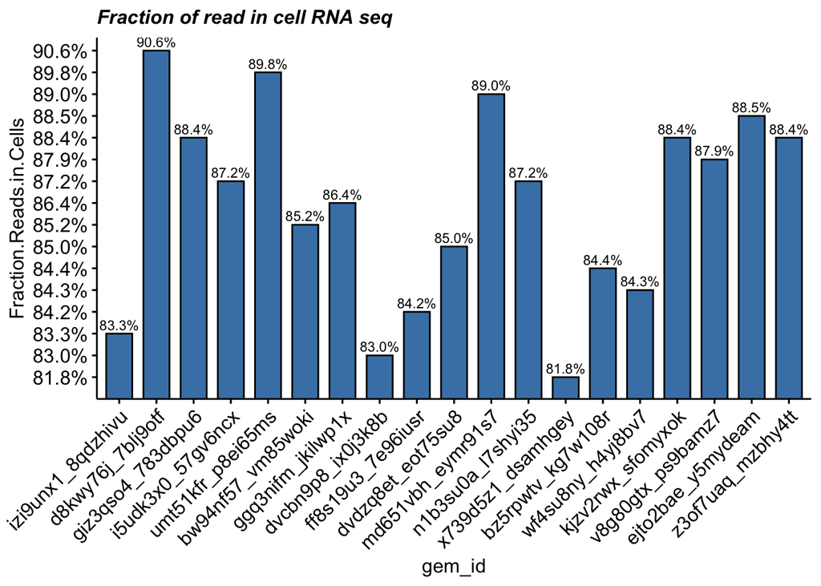

```r
par(mar=c(8,4,2,2),mgp=c(3, 1, 0))

p<- ggbarplot(RNAseq.data.mapping,
          x="gem_id",
           y="Fraction.Reads.in.Cells",
          fill="steelblue",
          lab.col = "black",
          lab.pos = "out",
          lab.size = 3,
          ggtheme = theme_pubr(x.text.angle = 45),
          label = TRUE,
          title = "Fraction of read in cell RNA seq"
          )
p+font("title", size = 12, face = "bold.italic") +
  geom_hline(yintercept=70,linetype="dashed", color = "red")
```

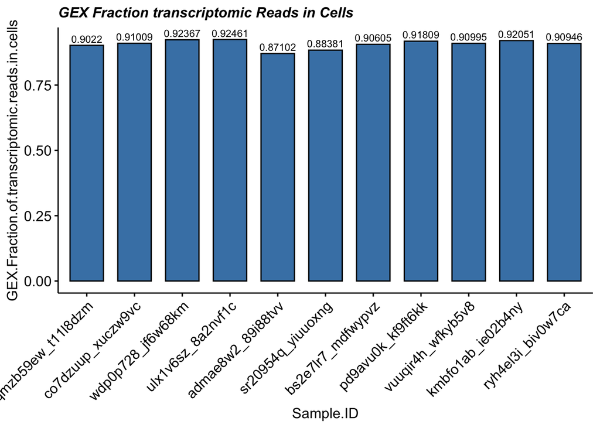

```r
par(mar=c(8,4,2,2),mgp=c(3, 1, 0))

p<- ggbarplot(Multiome.RNAseq.data.mapping,
          x="Sample.ID",
          y="GEX.Fraction.of.transcriptomic.reads.in.cells",
          fill="steelblue",
          lab.col = "black",
          lab.pos = "out",
          lab.size = 3,
          ggtheme = theme_pubr(x.text.angle = 45),
          label = TRUE,
          title = "GEX Fraction transcriptomic Reads in Cells"
          )
p+font("title", size = 12, face = "bold.italic")
```

## Read Mapped to Genome

Here, we want to take at look at how the fraction of reads mapped to genome behave in both methods.

We can observe that the values of Read mapped to the genome in RNA-seq vary much more than in Multiome GEX. Therefore we want to see if this is happened in the intergenic, intronic, exonic regions as well.

### RNA-seq

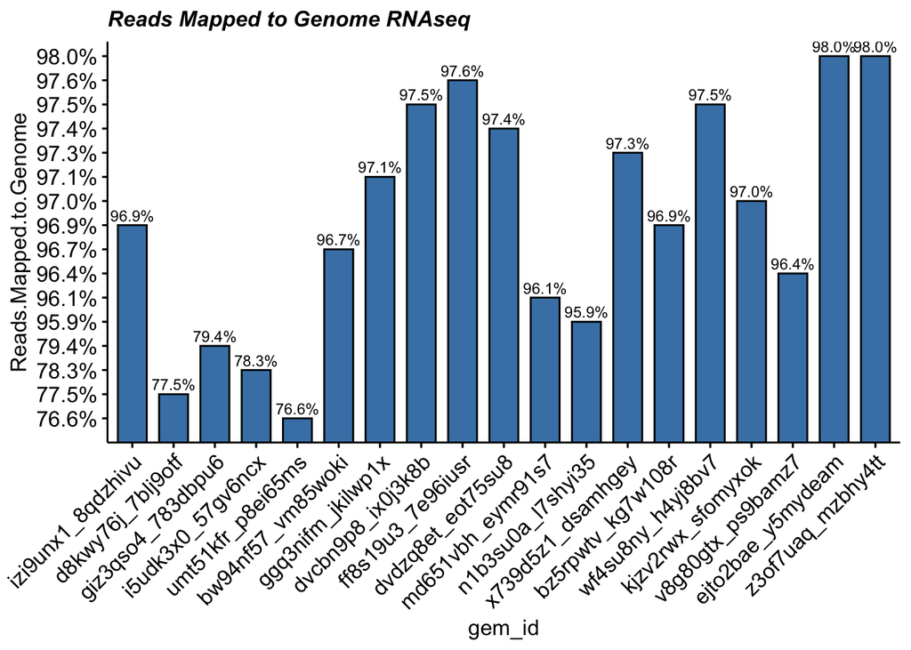

```r
par(mar=c(8,4,2,2),mgp=c(3, 1, 0))
p<- ggbarplot(RNAseq.data.mapping,
          x="gem_id",
           y="Reads.Mapped.to.Genome",
          fill="steelblue",
          lab.col = "black",
          lab.pos = "out",
          lab.size = 3,
          ggtheme = theme_pubr(x.text.angle = 45),
          label = TRUE,
          title = "Reads Mapped to Genome RNAseq"
          )
p+font("title", size = 12, face = "bold.italic")
```

### GEX multiome

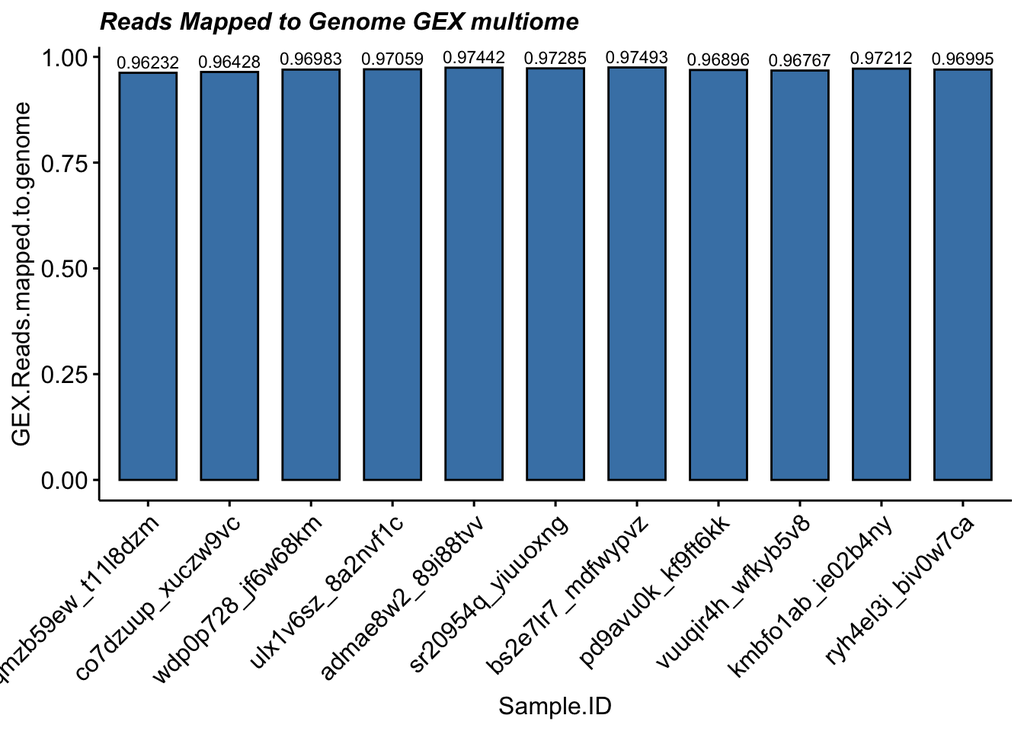

```r
p<- ggbarplot(Multiome.RNAseq.data.mapping,
          x="Sample.ID",
           y="GEX.Reads.mapped.to.genome",
          fill="steelblue",
          lab.col = "black",
          lab.pos = "out",
          lab.size = 3,
          ggtheme = theme_pubr(x.text.angle = 45),
          label = TRUE,
          title = "Reads Mapped to Genome GEX multiome"
          )
p+font("title", size = 12, face = "bold.italic")
```

# Compare Fraction of reads mapped between RNA-seq and Multiome GEX

Now we compare the fraction of mapped reads to genome and the fraction of coffidently mapped to genone and mapped to intergenic, intronic and exonic regions between RNA-seq and multiome methods.

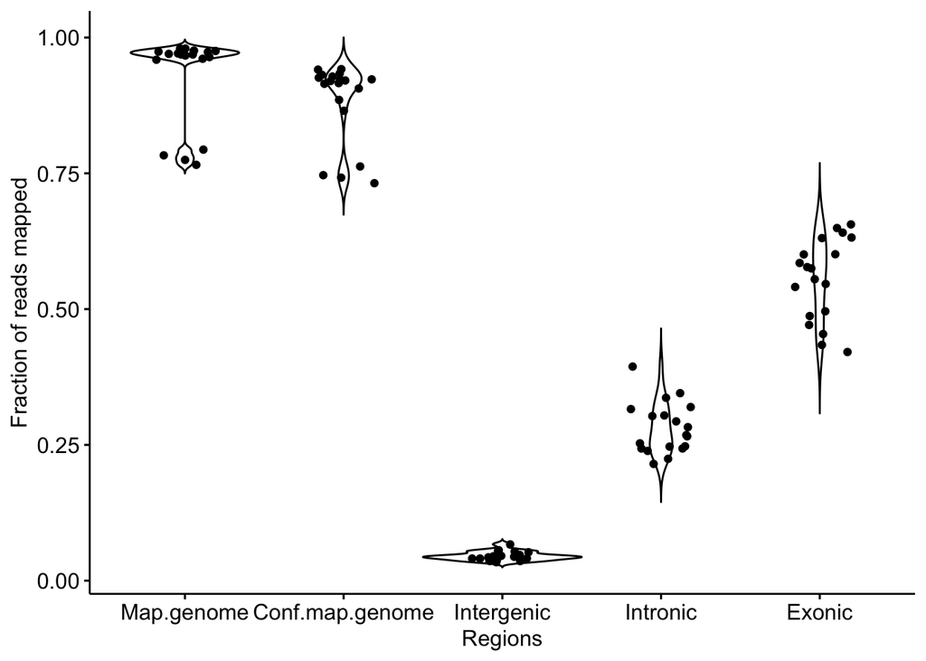

```r
RNAseq.data.fraction.melted<-melt (RNAseq.data.mapping[,
                        c("gem_id",
                                             "Reads.Mapped.to.Genome",
                                             "Reads.Mapped.Confidently.to.Genome",
                                             "Reads.Mapped.Confidently.to.Intergenic.Regions",
                                             "Reads.Mapped.Confidently.to.Intronic.Regions",
                                             "Reads.Mapped.Confidently.to.Exonic.Regions")],id.var="gem_id")

RNAseq.data.fraction.melted$variable<- revalue(RNAseq.data.fraction.melted$variable,
                                        c( "Reads.Mapped.to.Genome"="Map.genome",
                                           "Reads.Mapped.Confidently.to.Genome" = "Conf.map.genome",
                                           "Reads.Mapped.Confidently.to.Intergenic.Regions"="Intergenic",
                                           "Reads.Mapped.Confidently.to.Intronic.Regions" = "Intronic",
        "Reads.Mapped.Confidently.to.Exonic.Regions" = "Exonic"),
        warn_missing = TRUE)


RNAseq.data.fraction.melted$value<-as.numeric(sub("%","",RNAseq.data.fraction.melted$value))/100

ggviolin(
  RNAseq.data.fraction.melted,
  x="variable",
  y="value",
  xlab = "Regions",
  ylab = "Fraction of reads mapped",
  add = "jitter")
```

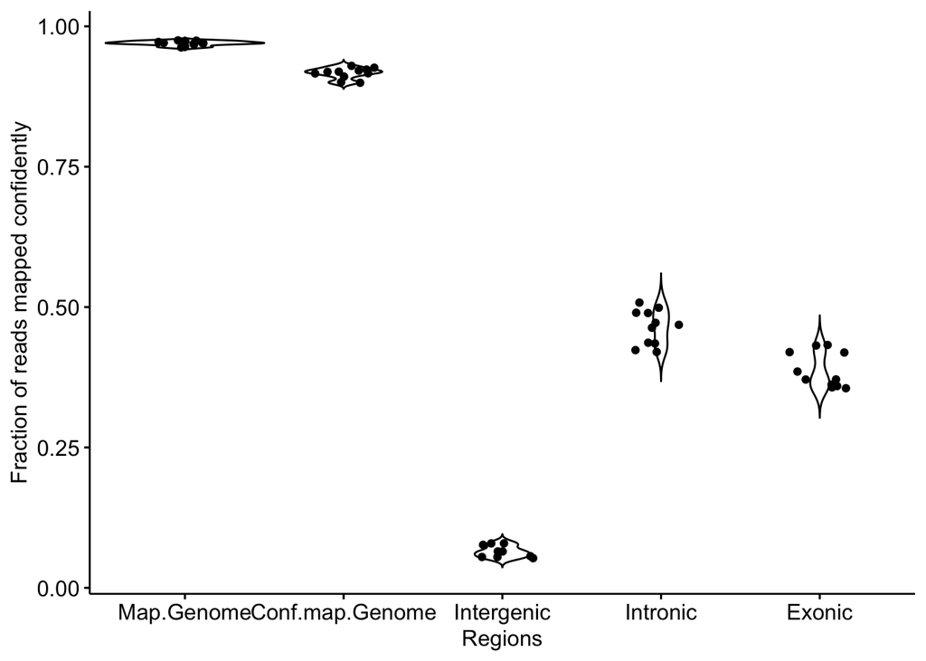

```r
Multiome.data.fraction.melted<-melt(Multiome.RNAseq.data.mapping[,c("Sample.ID","GEX.Reads.mapped.to.genome","GEX.Reads.mapped.confidently.to.genome","GEX.Reads.mapped.confidently.to.intergenic.regions","GEX.Reads.mapped.confidently.to.intronic.regions","GEX.Reads.mapped.confidently.to.exonic.regions")],id.vars = "Sample.ID")
Multiome.data.fraction.melted$variable<- revalue(Multiome.data.fraction.melted$variable,
                                                 c("GEX.Reads.mapped.to.genome"="Map.Genome",
                                                   "GEX.Reads.mapped.confidently.to.genome"="Conf.map.Genome",
                                                   "GEX.Reads.mapped.confidently.to.intergenic.regions" = "Intergenic",
        "GEX.Reads.mapped.confidently.to.intronic.regions" = "Intronic",
        "GEX.Reads.mapped.confidently.to.exonic.regions" = "Exonic"),
        warn_missing = TRUE)

ggviolin(
  Multiome.data.fraction.melted,
  x="variable",
  y="value",
  xlab = "Regions",
  ylab = "Fraction of reads mapped confidently",
  add = "jitter")
```

## Comparing RNA-seq and multiome reads mapped to genome

However, as we mentioned earlier, the data from the RNA-seqmethod seems to have more variability than that of the multiome GEX. This could be because there are more samples in the RNA-seq and it is more likely to find differences between samples, or it could be related to the methodology.

The proportion of reads assigned to the exotic and intronic regions of the sample from the RNA-seq shows greater variability than in the multiome

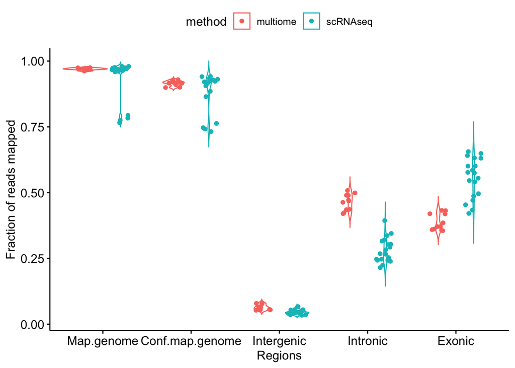

```r
RNAseq.data.fraction.melted.2<-melt (RNAseq.data.mapping[,
                        c("method",
                                             "Reads.Mapped.to.Genome",
                                             "Reads.Mapped.Confidently.to.Genome",
                                             "Reads.Mapped.Confidently.to.Intergenic.Regions",
                                             "Reads.Mapped.Confidently.to.Intronic.Regions",
                                             "Reads.Mapped.Confidently.to.Exonic.Regions")],id.var="method")

RNAseq.data.fraction.melted.2$variable<- revalue(RNAseq.data.fraction.melted.2$variable,
                                        c( "Reads.Mapped.to.Genome"="Map.genome",
                                           "Reads.Mapped.Confidently.to.Genome" = "Conf.map.genome",
                                           "Reads.Mapped.Confidently.to.Intergenic.Regions"="Intergenic",
                                           "Reads.Mapped.Confidently.to.Intronic.Regions" = "Intronic",
        "Reads.Mapped.Confidently.to.Exonic.Regions" = "Exonic"),
        warn_missing = TRUE)


RNAseq.data.fraction.melted.2$value<-as.numeric(sub("%","",RNAseq.data.fraction.melted.2$value))/100

# multiome melt

Multiome.data.fraction.melted.2<-melt(Multiome.RNAseq.data.mapping[,c("method","GEX.Reads.mapped.to.genome","GEX.Reads.mapped.confidently.to.genome","GEX.Reads.mapped.confidently.to.intergenic.regions","GEX.Reads.mapped.confidently.to.intronic.regions","GEX.Reads.mapped.confidently.to.exonic.regions")],id.vars = "method")

Multiome.data.fraction.melted.2$variable<- revalue(Multiome.data.fraction.melted.2$variable,
                                                 c("GEX.Reads.mapped.to.genome"="Map.genome",
                                                   "GEX.Reads.mapped.confidently.to.genome"="Conf.map.genome",
                                                   "GEX.Reads.mapped.confidently.to.intergenic.regions" = "Intergenic",
        "GEX.Reads.mapped.confidently.to.intronic.regions" = "Intronic",
        "GEX.Reads.mapped.confidently.to.exonic.regions" = "Exonic"),
        warn_missing = TRUE)
ALL.data<- merge(RNAseq.data.fraction.melted.2,Multiome.data.fraction.melted.2,all = TRUE)

ggviolin(
  ALL.data,
  x="variable",
  y="value",
  xlab = "Regions",
  ylab = "Fraction of reads mapped",
  add = "jitter",
  color = "method")
```

#### Comparing Read mapped antisense to gene in RNA-seq and Multiome GEX

Here we compare the proportion of reads mapped antisense to gene in RNA-seq and Multiome GEX in a separate violin plot, as the values in RNA-seq were significantly lower than the other variables and it was difficult to see them all in the same plot.

In this case, the data between Multiome and RNA-seq are very different. We can see that we can capture a higher percentage of reads mapped to antisense RNA using the Multiome method than using the RNA-seq method.

Also, it is shows that the variablity of the results in multiome is higher in this case. Whereas, in RNA-seq the fraction is very uniform we find all of them around 2 % and 3%.

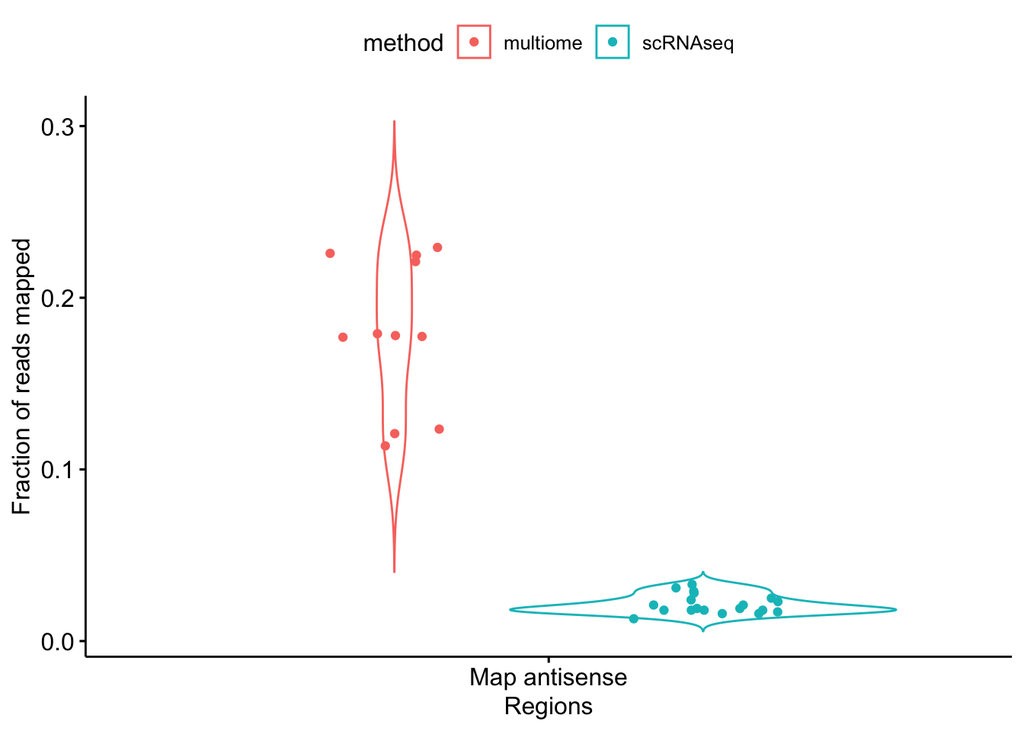

```r
RNAseq.data.fraction.melted.3<-melt (RNAseq.data.mapping[,
                        c("method",
                                             "Reads.Mapped.Antisense.to.Gene")],id.var="method")

RNAseq.data.fraction.melted.3$variable<- revalue(RNAseq.data.fraction.melted.3$variable,
                                        c( "Reads.Mapped.Antisense.to.Gene"="Map antisense"
                                           ),
        warn_missing = TRUE)


RNAseq.data.fraction.melted.3$value<-as.numeric(sub("%","",RNAseq.data.fraction.melted.3$value))/100

# multiome melt

Multiome.data.fraction.melted.3<-melt(Multiome.RNAseq.data.mapping[,c("method","GEX.Reads.mapped.antisense.to.gene")],id.vars = "method")

Multiome.data.fraction.melted.3$variable<- revalue(Multiome.data.fraction.melted.3$variable,
                                                 c("GEX.Reads.mapped.antisense.to.gene"="Map antisense"
                                                   ),
        warn_missing = TRUE)
ALL.data.2<- merge(RNAseq.data.fraction.melted.3,Multiome.data.fraction.melted.3,all = TRUE)

ggviolin(
  ALL.data.2,
  x="variable",
  y="value",
  xlab = "Regions",
  ylab = "Fraction of reads mapped",
  add = "jitter",
  color = "method")
```